# Introduction to R and the Tidyverse

### Summarising data

```r
fev_data %>%
  filter(age == 14, smoke != 0) %>%
  summarise(mean(fev))
```

```
## # A tibble: 1 x 1
##   `mean(fev)`
##         <dbl>
## 1        3.43
```

You can name the summary variable:

```r
fev_data %>%
  filter(age == 14, smoke != 0) %>%
  summarise(my_mean = mean(fev))
```

```
## # A tibble: 1 x 1
##   my_mean
##     <dbl>
## 1    3.43
```

```r
fev_data %>%
  filter(age == 14, smoke != 0) %>%
  summarise(mean(fev), sd(fev))
```

```
## # A tibble: 1 x 2
##   `mean(fev)` `sd(fev)`
##         <dbl>     <dbl>
## 1        3.43     0.976
```

To get the average FEV for both smokers and non-smokers we don’t need to repeat for smoke==0. We can create a grouping variable:

```r
fev_data %>%
  group_by(smoke)
```

```
## # A tibble: 654 x 7
## # Groups:   smoke [2]
##    seqnbr subjid   age   fev height   sex smoke
##     <dbl>  <dbl> <dbl> <dbl>  <dbl> <dbl> <dbl>
##  1      1    301     9  1.71   57       0     0
##  2      2    451     8  1.72   67.5     0     0
##  3      3    501     7  1.72   54.5     0     0
##  4      4    642     9  1.56   53       1     0
##  5      5    901     9  1.90   57       1     0
##  6      6   1701     8  2.34   61       0     0
##  7      7   1752     6  1.92   58       0     0
##  8      8   1753     6  1.42   56       0     0
##  9      9   1901     8  1.99   58.5     0     0
## 10     10   1951     9  1.94   60       0     0
## # ... with 644 more rows
```

(Same exact data, it just prints the two groups)

```r
fev_data %>%
  group_by(smoke) %>%
  summarise(mean(fev), sd(fev))
```

```
## # A tibble: 2 x 3
##   smoke `mean(fev)` `sd(fev)`
##   <dbl>       <dbl>     <dbl>
## 1     0        2.57     0.851
## 2     1        3.28     0.750
```

But what is the size of each group? n() gives us the number of observations in each group:

```r
fev_data %>%
  group_by(smoke) %>%
  summarise(n = n(), mean = mean(fev), sd = sd(fev))
```

```
## # A tibble: 2 x 4
##   smoke     n  mean    sd
##   <dbl> <int> <dbl> <dbl>
## 1     0   589  2.57 0.851
## 2     1    65  3.28 0.750
```

You can also group by your own variables:

```r
fev_data %>%
  group_by(height < 60) %>%
  summarise(n(), mean(fev))
```

```
## # A tibble: 2 x 3
##   `height < 60` `n()` `mean(fev)`
##   <lgl>         <int>       <dbl>
## 1 FALSE           409        3.10
## 2 TRUE            245        1.86
```

A useful function: arrange

```r
fev_data %>%
  group_by(age) %>%
  summarise(n(), mean(fev)) %>%
  arrange(age) # arrange by increasing age
```

```
## # A tibble: 17 x 3
##      age `n()` `mean(fev)`
##    <dbl> <int>       <dbl>
##  1     3     2        1.24
##  2     4     9        1.28
##  3     5    28        1.55
##  4     6    37        1.66
##  5     7    54        1.87
##  6     8    85        2.12
##  7     9    94        2.43
##  8    10    81        2.69
##  9    11    90        3.04
## 10    12    57        3.22
## 11    13    43        3.48
## 12    14    25        3.58
## 13    15    19        3.48
## 14    16    13        3.67
## 15    17     8        4.30
## 16    18     6        3.59
## 17    19     3        3.99
```

```r
fev_data %>%
  group_by(age) %>%
  summarise(n(), mean(fev)) %>%
  arrange(desc(age)) # arrange by decreasing age
```

```
## # A tibble: 17 x 3
##      age `n()` `mean(fev)`
##    <dbl> <int>       <dbl>
##  1    19     3        3.99
##  2    18     6        3.59
##  3    17     8        4.30
##  4    16    13        3.67
##  5    15    19        3.48
##  6    14    25        3.58
##  7    13    43        3.48
##  8    12    57        3.22
##  9    11    90        3.04
## 10    10    81        2.69
## 11     9    94        2.43
## 12     8    85        2.12
## 13     7    54        1.87
## 14     6    37        1.66
## 15     5    28        1.55
## 16     4     9        1.28
## 17     3     2        1.24
```

```r
fev_data$age %>% sort #S ort a column
```

```
##   [1]  3  3  4  4  4  4  4  4  4  4  4  5  5  5  5  5  5  5  5  5  5  5  5
##  [24]  5  5  5  5  5  5  5  5  5  5  5  5  5  5  5  5  6  6  6  6  6  6  6
##  [47]  6  6  6  6  6  6  6  6  6  6  6  6  6  6  6  6  6  6  6  6  6  6  6
##  [70]  6  6  6  6  6  6  6  7  7  7  7  7  7  7  7  7  7  7  7  7  7  7  7
##  [93]  7  7  7  7  7  7  7  7  7  7  7  7  7  7  7  7  7  7  7  7  7  7  7
## [116]  7  7  7  7  7  7  7  7  7  7  7  7  7  7  7  8  8  8  8  8  8  8  8
## [139]  8  8  8  8  8  8  8  8  8  8  8  8  8  8  8  8  8  8  8  8  8  8  8
## [162]  8  8  8  8  8  8  8  8  8  8  8  8  8  8  8  8  8  8  8  8  8  8  8
## [185]  8  8  8  8  8  8  8  8  8  8  8  8  8  8  8  8  8  8  8  8  8  8  8
## [208]  8  8  8  8  8  8  8  8  9  9  9  9  9  9  9  9  9  9  9  9  9  9  9
## [231]  9  9  9  9  9  9  9  9  9  9  9  9  9  9  9  9  9  9  9  9  9  9  9
## [254]  9  9  9  9  9  9  9  9  9  9  9  9  9  9  9  9  9  9  9  9  9  9  9
## [277]  9  9  9  9  9  9  9  9  9  9  9  9  9  9  9  9  9  9  9  9  9  9  9
## [300]  9  9  9  9  9  9  9  9  9  9 10 10 10 10 10 10 10 10 10 10 10 10 10
## [323] 10 10 10 10 10 10 10 10 10 10 10 10 10 10 10 10 10 10 10 10 10 10 10
## [346] 10 10 10 10 10 10 10 10 10 10 10 10 10 10 10 10 10 10 10 10 10 10 10
## [369] 10 10 10 10 10 10 10 10 10 10 10 10 10 10 10 10 10 10 10 10 10 10 11
## [392] 11 11 11 11 11 11 11 11 11 11 11 11 11 11 11 11 11 11 11 11 11 11 11
## [415] 11 11 11 11 11 11 11 11 11 11 11 11 11 11 11 11 11 11 11 11 11 11 11
## [438] 11 11 11 11 11 11 11 11 11 11 11 11 11 11 11 11 11 11 11 11 11 11 11
## [461] 11 11 11 11 11 11 11 11 11 11 11 11 11 11 11 11 11 11 11 11 12 12 12
## [484] 12 12 12 12 12 12 12 12 12 12 12 12 12 12 12 12 12 12 12 12 12 12 12
## [507] 12 12 12 12 12 12 12 12 12 12 12 12 12 12 12 12 12 12 12 12 12 12 12
## [530] 12 12 12 12 12 12 12 12 13 13 13 13 13 13 13 13 13 13 13 13 13 13 13
## [553] 13 13 13 13 13 13 13 13 13 13 13 13 13 13 13 13 13 13 13 13 13 13 13
## [576] 13 13 13 13 13 14 14 14 14 14 14 14 14 14 14 14 14 14 14 14 14 14 14
## [599] 14 14 14 14 14 14 14 15 15 15 15 15 15 15 15 15 15 15 15 15 15 15 15
## [622] 15 15 15 16 16 16 16 16 16 16 16 16 16 16 16 16 17 17 17 17 17 17 17
## [645] 17 18 18 18 18 18 18 19 19 19
```

```r
fev_data$age %>% unique %>% sort # Sort unique values in a column
```

```
##  [1]  3  4  5  6  7  8  9 10 11 12 13 14 15 16 17 18 19
```

–> **Problem 1**: Which subjects are male and which are female? (i.e. what does sex == 1 mean?)

```r
# Add your code here!
```

–> **Problem 2**: Why do smokers appear to have better lung function (higher forced expiratory volume - FEV)?

```r
# Add your code here!
```

Useful function: rename

```r
fev_data %>%
  rename(ID = subjid)
```

```
## # A tibble: 654 x 7
##    seqnbr    ID   age   fev height   sex smoke
##     <dbl> <dbl> <dbl> <dbl>  <dbl> <dbl> <dbl>
##  1      1   301     9  1.71   57       0     0
##  2      2   451     8  1.72   67.5     0     0
##  3      3   501     7  1.72   54.5     0     0
##  4      4   642     9  1.56   53       1     0
##  5      5   901     9  1.90   57       1     0
##  6      6  1701     8  2.34   61       0     0
##  7      7  1752     6  1.92   58       0     0
##  8      8  1753     6  1.42   56       0     0
##  9      9  1901     8  1.99   58.5     0     0
## 10     10  1951     9  1.94   60       0     0
## # ... with 644 more rows
```

Mutate: compute new column

```r
fev_data %>%
  mutate(heightdiff = height - mean(height))
```

```
## # A tibble: 654 x 8
##    seqnbr subjid   age   fev height   sex smoke heightdiff
##     <dbl>  <dbl> <dbl> <dbl>  <dbl> <dbl> <dbl>      <dbl>
##  1      1    301     9  1.71   57       0     0     -4.14
##  2      2    451     8  1.72   67.5     0     0      6.36
##  3      3    501     7  1.72   54.5     0     0     -6.64
##  4      4    642     9  1.56   53       1     0     -8.14
##  5      5    901     9  1.90   57       1     0     -4.14
##  6      6   1701     8  2.34   61       0     0     -0.144
##  7      7   1752     6  1.92   58       0     0     -3.14
##  8      8   1753     6  1.42   56       0     0     -5.14
##  9      9   1901     8  1.99   58.5     0     0     -2.64
## 10     10   1951     9  1.94   60       0     0     -1.14
## # ... with 644 more rows
```

Remember that to save these changes you need to assign to a new tibble:

```r
new_fev_data <- fev_data %>%
  rename(id = subjid) %>%
  mutate(heightdiff = height - mean(height))
```

### Plotting

The first step to using ggplot is creating a blank canvas:

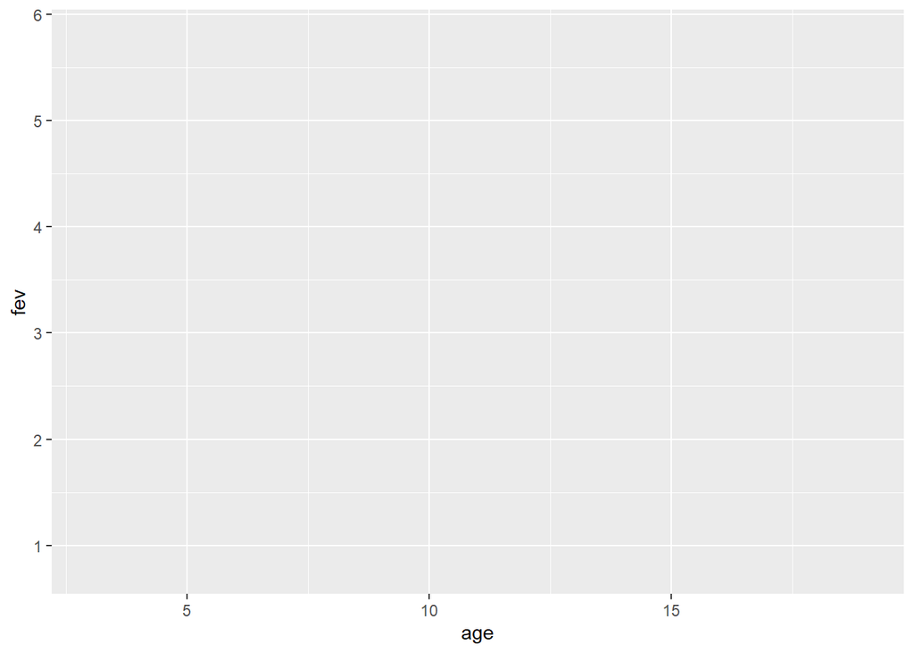

```r
fev_data %>%
  ggplot(aes(x = age, y = fev))   # aes stands for "aesthetic"
```

### Scatterplots

We add points using geom_point:

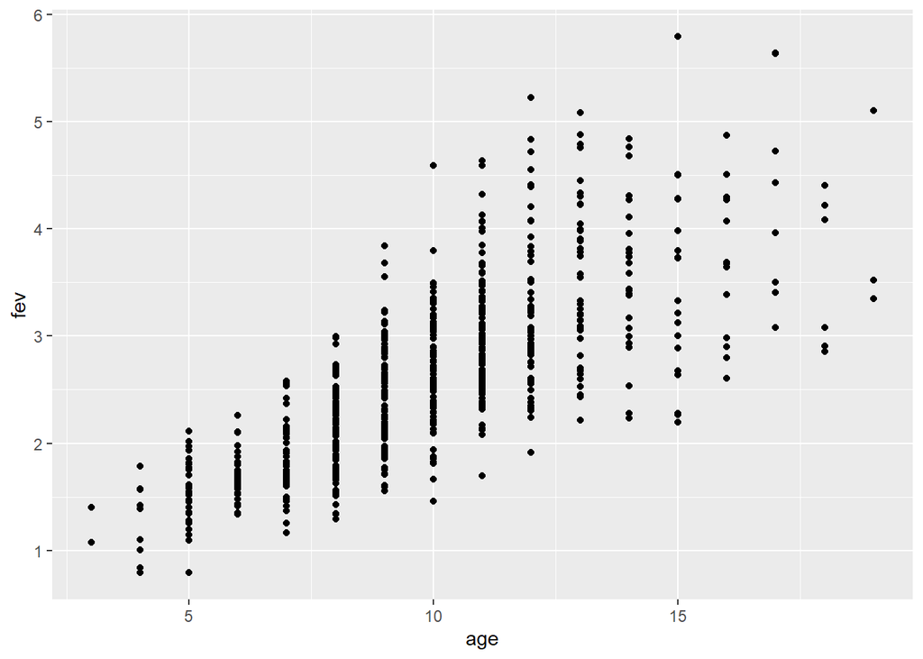

```r
fev_data %>%
  ggplot(aes(x = age, y = fev)) +
  geom_point()
```

Add limits, labels, title:

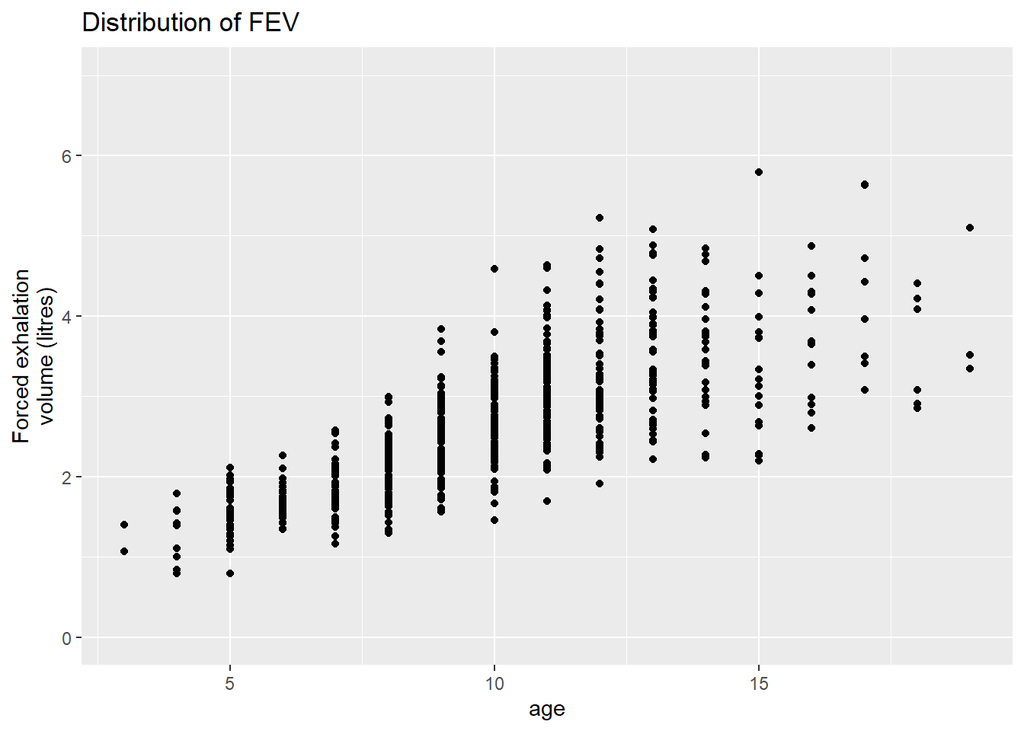

```r
fev_data %>%
  ggplot(aes(x = age, y = fev)) +
  geom_point() +
  ylim(0, 7) +
  ylab("Forced exhalation\nvolume (litres)") +
  ggtitle("Distribution of FEV")
```

We can change the colour of the points (col), the shape of the points (pch) and the size (cex):

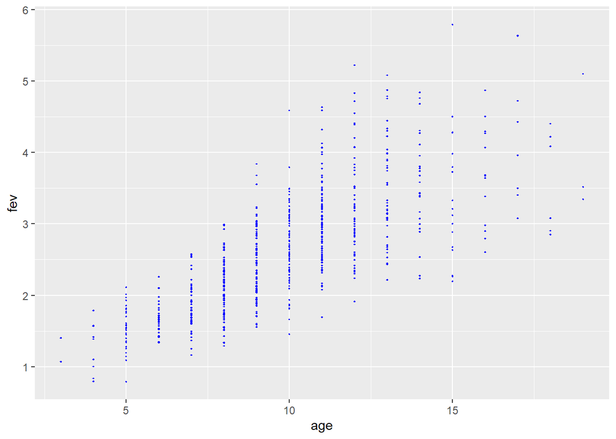

```r
fev_data %>%
  ggplot(aes(x = age, y = fev)) +
  geom_point(cex = 0.5, pch = 18, col = "blue")  # Half as small, filled diamonds, blue
```

Tip: Find out more about ggplot’s aesthetic specifications here: https://cran.r-project.org/web/packages/ggplot2/vignettes/ggplot2-specs.html

To colour by sex or smoking status, we add the variables as aesthetic elements:

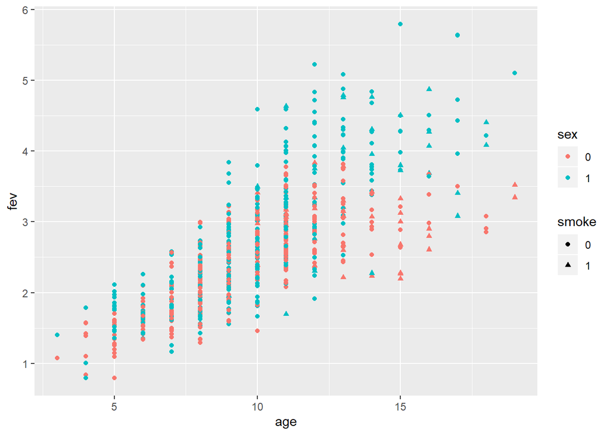

```r
fev_data %>%
  mutate(sex = as.character(sex),
         smoke = as.character(smoke)) %>% # change sex and smoke from continuous to categorical variables
  ggplot(aes(x = age, y = fev)) +
  geom_point(aes(col = sex, pch = smoke))
```

Add a smooth line fitted to the data:

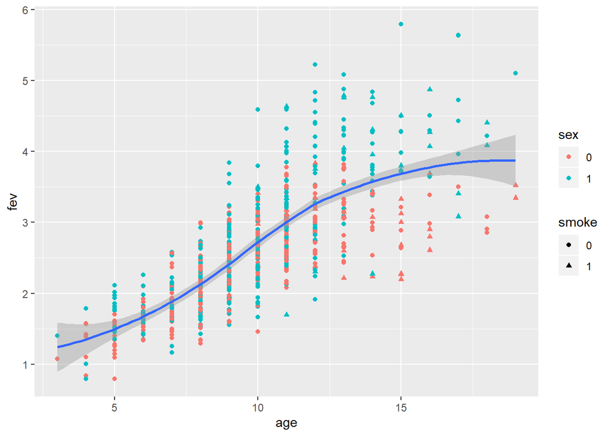

```r
fev_data %>%
  mutate(sex = as.character(sex),
         smoke = as.character(smoke)) %>%
  ggplot(aes(x = age, y = fev)) +
  geom_point(aes(col = sex, pch = smoke)) +
  geom_smooth()
```

One smooth line per sex:

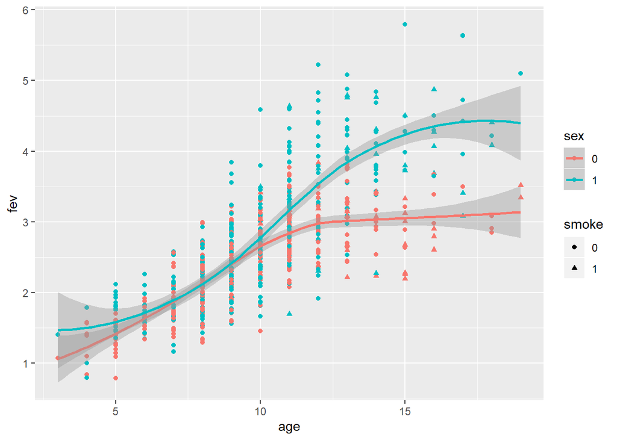

```r
fev_data %>%
  mutate(sex = as.character(sex),
         smoke = as.character(smoke)) %>%
  ggplot(aes(x = age, y = fev)) +
  geom_point(aes(col = sex, pch = smoke)) +
  geom_smooth(aes(col=sex))
```

One smooth line per sex or smoking status:

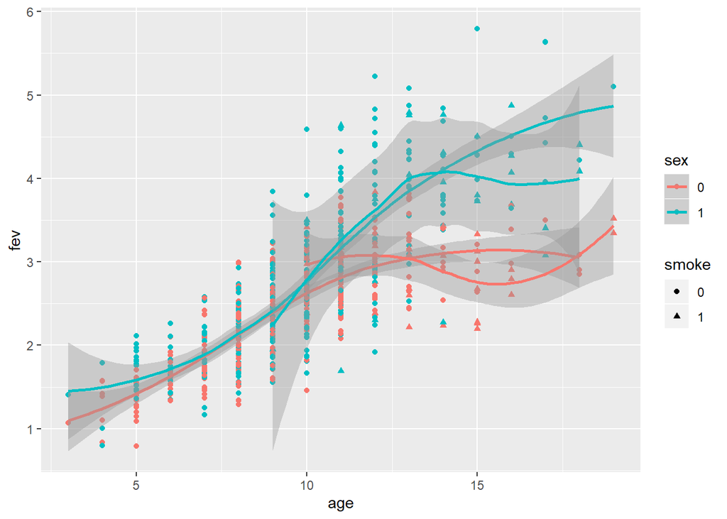

```r
fev_data %>%
  mutate(sex = as.character(sex),
         smoke = as.character(smoke)) %>%
  ggplot(aes(x = age, y = fev)) +
  geom_point(aes(col = sex, pch = smoke)) +
  geom_smooth(aes(col=sex, pch = smoke))
```

or:

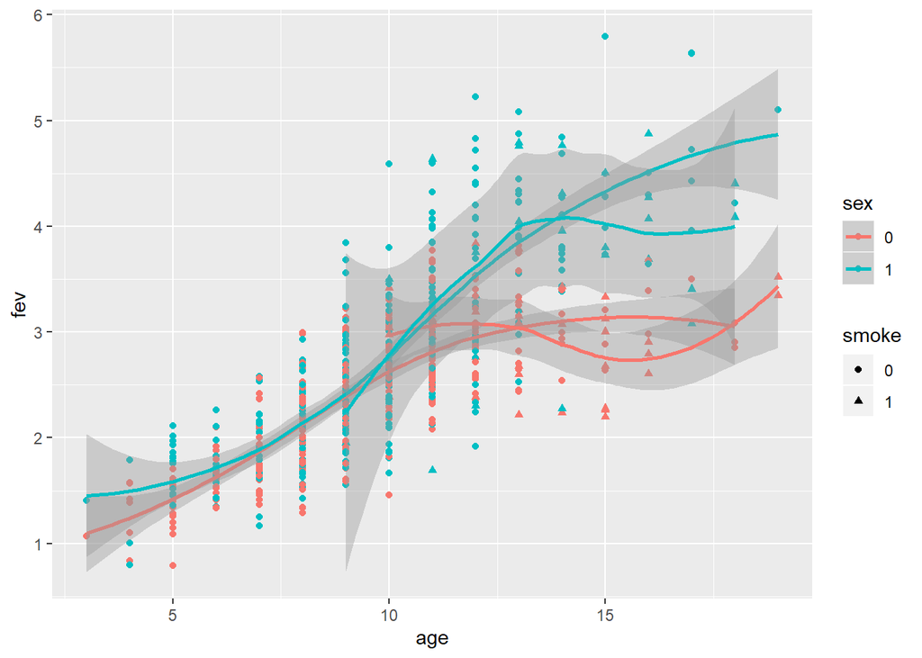

```r
fev_data %>%
  mutate(sex = as.character(sex),
         smoke = as.character(smoke)) %>%
  ggplot(aes(x = age, y = fev, col = sex, pch = smoke)) +
  geom_point() +
  geom_smooth()
```

### Line plots

```r
fev_average <- fev_data %>%
  group_by(age, smoke) %>%
  summarise(fev_mean = mean(fev))
```

This is not quite right:

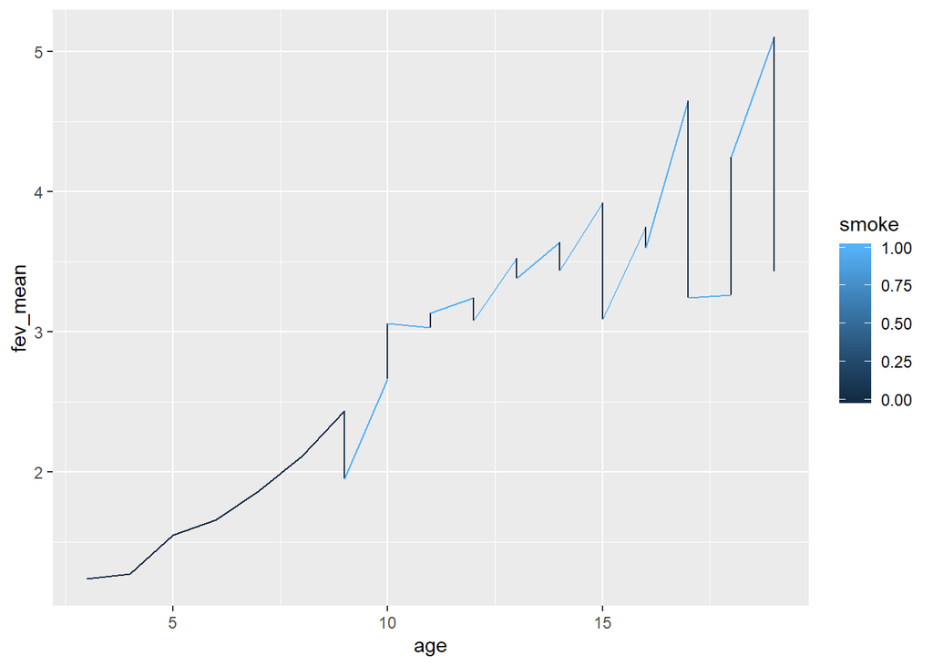

```r
fev_average %>%
  ggplot(aes(x = age, y = fev_mean)) +
  geom_line(aes(col = smoke))  # smoke is a continuous numeric variable!
```

This is better :)

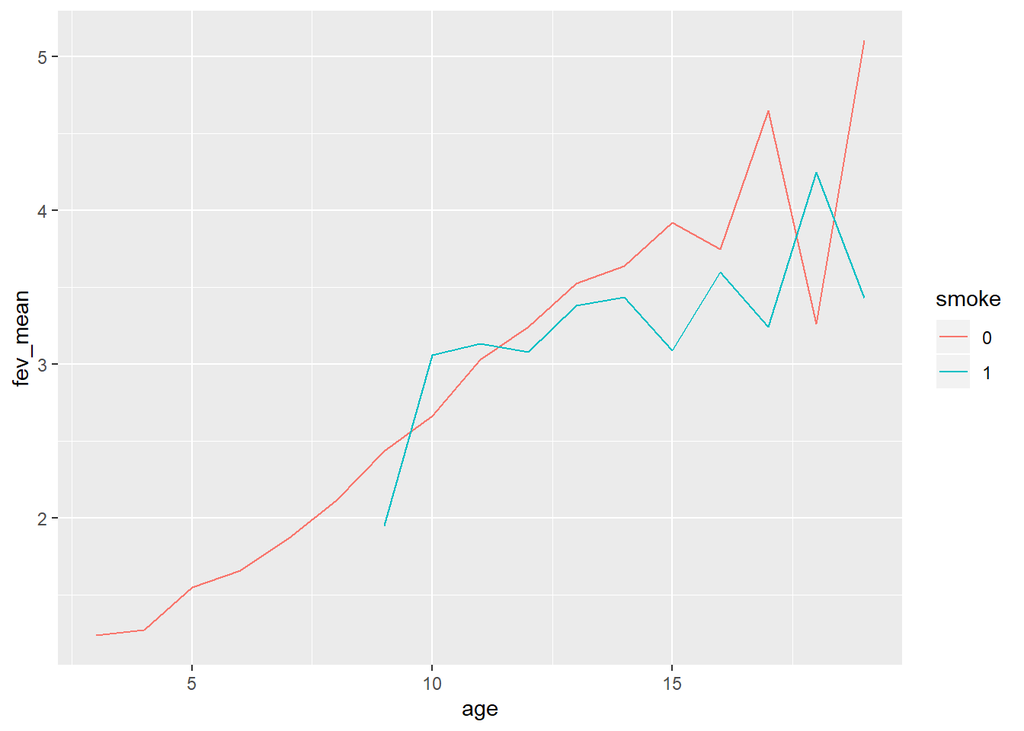

```r
fev_average %>%
  mutate(smoke = as.character(smoke)) %>%
  ggplot(aes(x = age, y = fev_mean)) +
  geom_line(aes(col = smoke))
```

### Bar plots

How many subjects smoke?

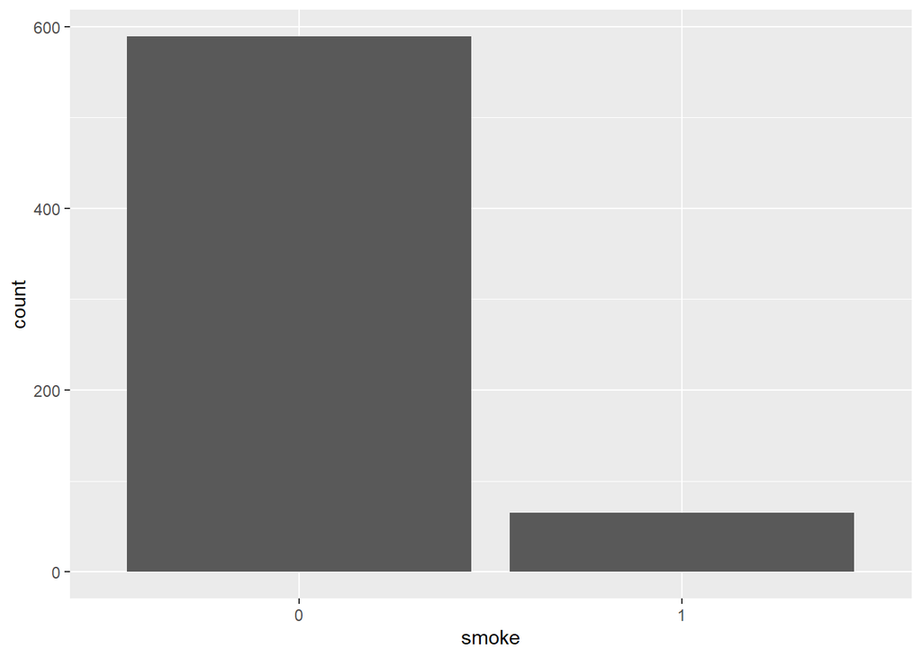

```r
fev_data %>%
  mutate(smoke = as.character(smoke)) %>%
  ggplot(aes(x = smoke)) +
  geom_bar()  # by default, the y variable is the count of the x (in this case, number of smokers)
```

How many men and how many women smoke / don’t smoke?

```r
fev_count <- fev_data %>%
  group_by(sex, smoke) %>%
  summarise(smoke_count = n())
```

It might be easier to replace 0 and 1 with meaningful words…

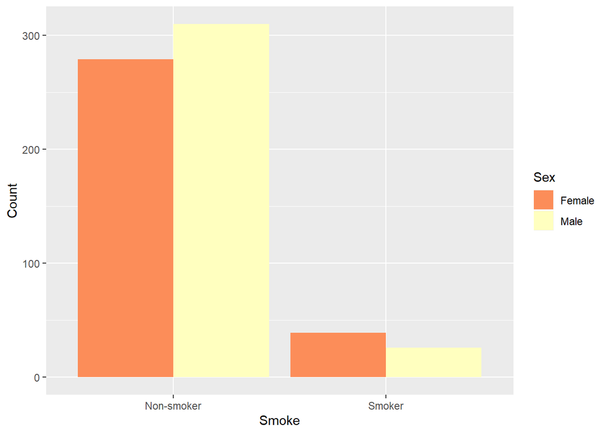

```r
fev_count <- fev_data %>%
  mutate(Smoke = ifelse(smoke == 1, "Smoker", "Non-smoker"),
         Sex = ifelse(sex == 1, "Male", "Female")) %>%
  group_by(Sex, Smoke) %>%
  summarise(Count = n())

fev_count %>%
  ggplot(aes(x = Smoke, y = Count, fill = Sex)) +
  geom_bar(stat = "identity",     # "identity" allows us to specify a y variable, otherwise it is count (as above)
           position = "dodge") +  # Put bars side-by-side instead of stacked
  scale_fill_brewer(palette="Spectral")
```

Tip: Find out much more about colours in ggplot here: http://www.cookbook-r.com/Graphs/Colors_(ggplot2)/

### Box plots

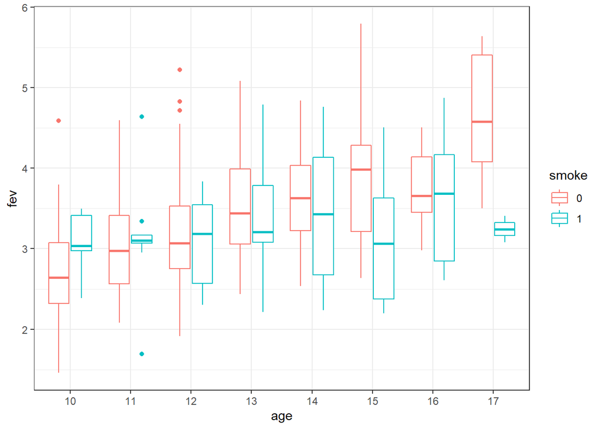

```r
fev_data %>%
  filter(age < 18 & age > 9) %>%
  mutate(smoke = as.character(smoke),
         age = as.character(age)) %>%
  ggplot(aes(x = age, y = fev, col = smoke)) +
  geom_boxplot() +
  theme_bw()
```

### Saving plots

```r
ggsave("age_vs_fev.pdf")
```

To change the size:

```r
ggsave("age_vs_fev.pdf", width=10, height=5)
```

### Case Study: Hip replacement outcomes for men and women in England

You have a csv file with patient reported outcomes in England (Hip Replacement CCG 1819.csv). We are interested in looking at gender differences when it comes to hip replacements. It comes from this NHS Visual Data Challenge: https://www.nuffieldtrust.org.uk/project/nhs-visual-data-challenge We want to create a compelling data visualisation about gender health differences. **Do you want to help?**

You are welcome to look at any outcome you like in the csv file, here are some suggestions:

1. How do the numbers of hip replacement procedures compare between men and women?
2. Compare pre- and post-operative ‘EQ-5D Index’ scores for men and women
3. Do patient reported outcomes correlate (visually) with conditions such as stroke, lung disease or diabetes?

```r
# Add your code here!
```

Thank you for taking part in our R workshop :)